# Part II - Ford Gobike Data Exploration

## by Teniola Alade

## Investigation Overview

The investigation mainly involved how the effect of the age, the gender, the user-type of each user with respect to the days of the week played a role in how long the duration of trip was.

## Dataset Overview

The dataset consists of information about 174,952 bike rides covering the greater San Francisco Bay area. The data features include duration (secs), age, user type, gender etc.

## Univariate Analysis

### Daily Bike Usage

More users rode the bike on Thursdays and Tuesdays, with a significant decrease on the weekends.

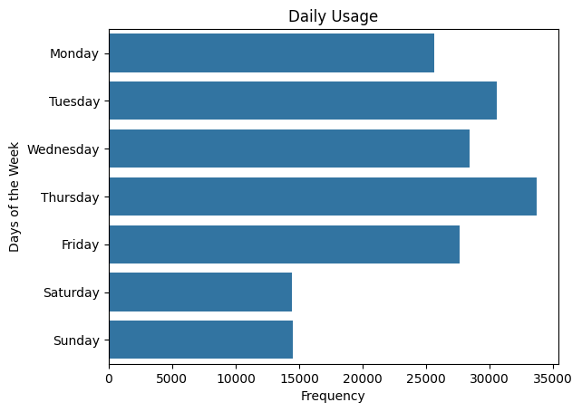

### Distribution by Gender

Most users were Men - above 120000 Men, while about one-third were Women and the users in the other category recorded the lowest number.

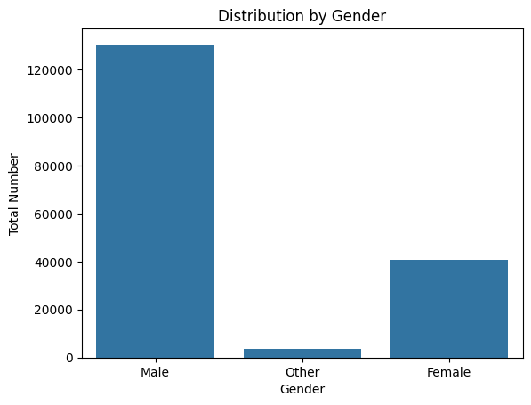

## Bivariate Analysis

### Daily Ride Durations

Users rode the bike for a longer duration on the weekends than weekdays.

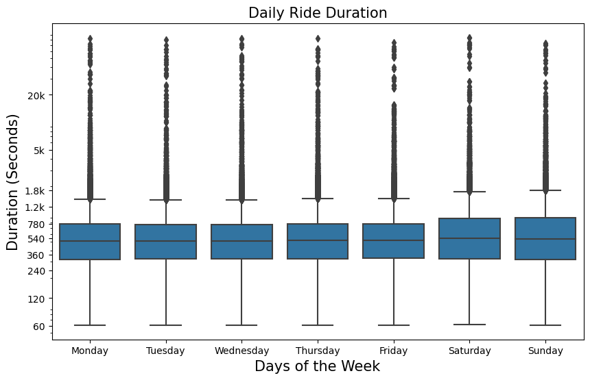

### Ride Duration against User-type

Customers rode the bike longer than the subscribers.

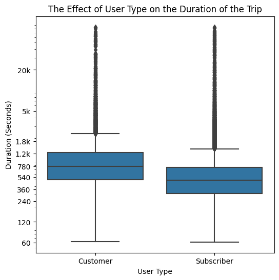

### Duration against Age

The olde rthe user, the shorter the trip duration and vice versa.

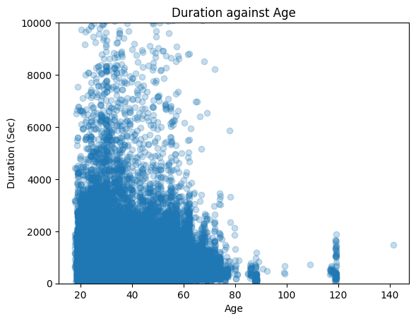

### Gender against Duration

Male users had the shortest average trip duration of the three gender categories, with the Female and Other being marginally close

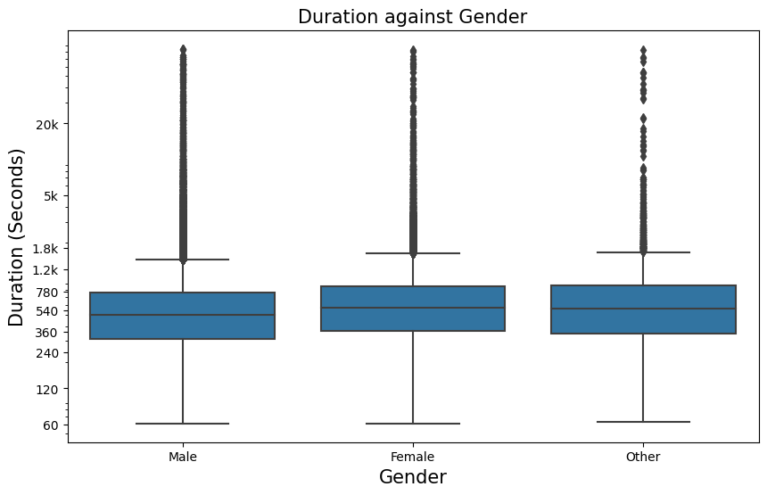

## Multivariate Analysis

### Daily Trip Duration by Gender

Other gender spent the most time on the bike. With the male gender spending the least time on the bike regardless of the day of the week. It also shows that all genders spent more time on the weekends than weekdays on the bike and the most time spent of the weekdays by the other gender was Thursday, followed by Monday.

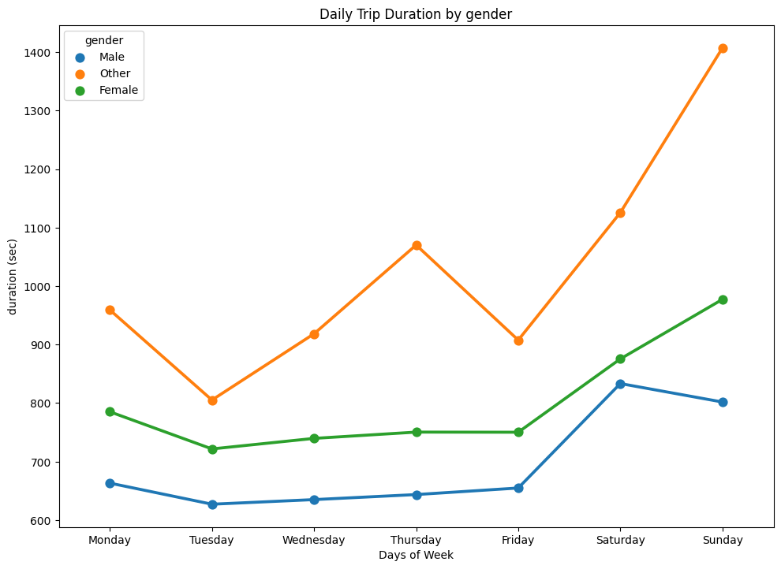

### Daily Trip Duration by User-Type

Customers spent a longer time riding the bike than the subscribers regardless of the day of the weeks, with both parties spending significantly more time on the weekends than weekdays. It can also be observed than customers spend more time on Monday than they did for any other weekday.

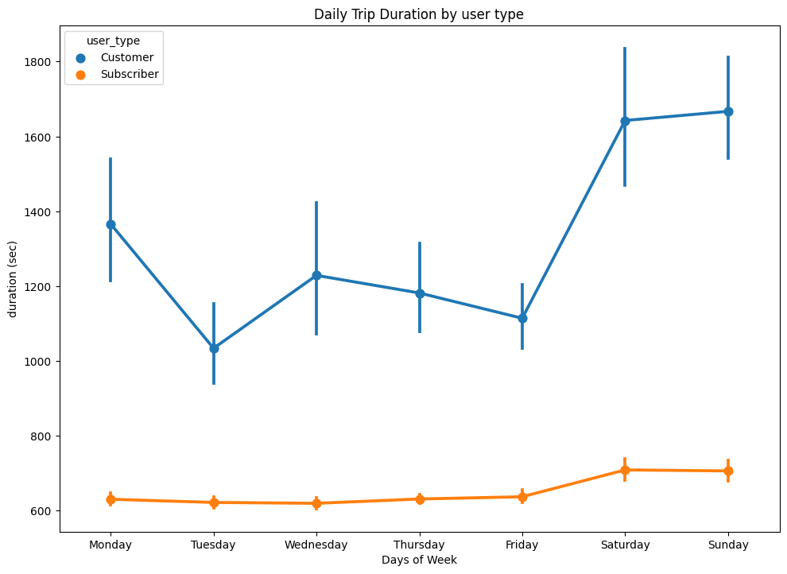